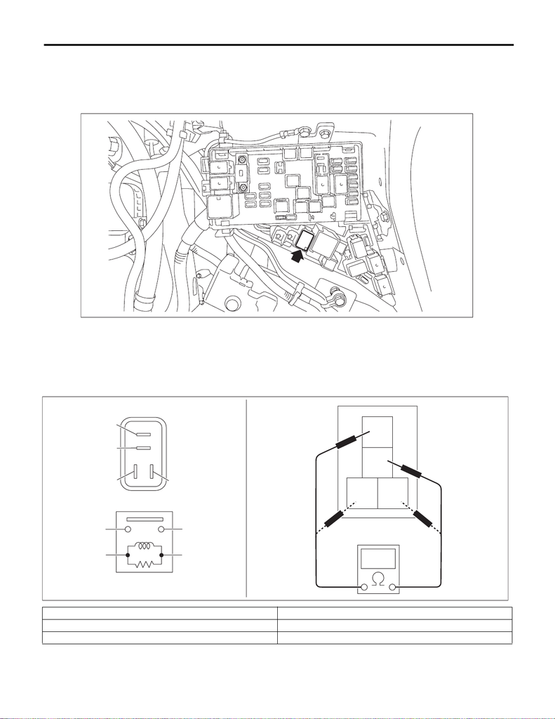

FU(w/o STI)-143

Fuel Injector Relay

FUEL INJECTION (FUEL SYSTEMS)

30.Fuel Injector Relay

A: REMOVAL

1) Disconnect the ground terminal from battery sensor. <Ref. to NT-5, BATTERY, NOTE, Note.>

2) Remove the fuel injector relay from main fuse box.

B: INSTALLATION

Install in the reverse order of removal.

C: INSPECTION

1) Check that the fuel injector relay has no deformation, cracks or other damages.

2) Measure the resistance between fuel injector relay terminals.

Terminal No. Standard

1 and 2 1 MΩ or more

3 and 4 93.8 — 136.4 Ω (when 20°C (68°F))

FU-08339

FU-05961

(1)

(2)

(1)

(4)

(2)

(3)

(3)

(4)

1

2

3

4

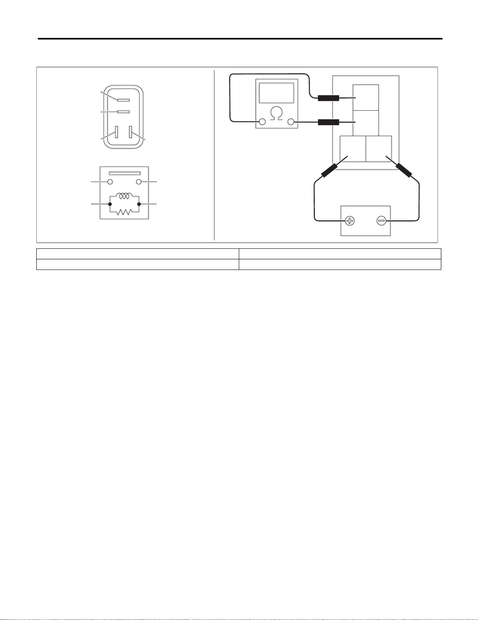

FU(w/o STI)-144

Fuel Injector Relay

FUEL INJECTION (FUEL SYSTEMS)

3) Connect battery positive terminal to terminal No. 3 and battery ground terminal to terminal No. 4, and mea-

sure the resistance between the fuel injector relay terminals.

Terminal No. Standard

1 and 2 Less than 1 Ω

FU-05963

(1)

(2)

(1)

(4)

(2)

(3)

(3)

(4)

1

2

3

4